# M2.891_20241_PEC1-Enunciado-1

[figure not shown]

M2.891 · Aprendizaje automático · PEC1

2024-1 · Máster universitario en Ciencia de datos (Data science)

Estudios de Informática, Multimedia y Telecomunicación

PEC 1: Preparación de datos

El objetivo principal de esta primera PEC es que os familiaricéis con el entorno de trabajo que utilizaréis en el resto de prácticas de la asignatura. Dicho entorno estará formado por un conjunto de dependencias relativas a ciertos módulos de Python que serán necesarios para poder ejecutar de forma correcta vuestra PEC. Estas dependencias las gestionaremos gracias a la ayuda de Anaconda. Otra de las herramientas fundamentales del que será vuestro nuevo entorno de trabajo será Jupyter, que os permitirá trabajar con Notebooks (ficheros *.ipynb) como el presente enunciado.

Otro de los aspectos más importantes que cubriremos en esta primera PEC, tal y como adelanta su título, es el de la preparación de los datos. En esta PEC aprenderemos a cargar un conjunto de datos o *dataset* y nos ayudaremos de herramientas de visualización para comprender mejor cómo se distribuye el dato de cara a entender cómo podemos sacarle partido. Además, nos habituaremos a trabajar con conjuntos de entrenamiento y test para confirmar si las conclusiones que sacamos sobre una parte de las muestras se pueden generalizar y extrapolar al resto.

En resumen, en esta práctica veremos cómo aplicar diferentes técnicas para la carga y preparación de datos siguiendo los pasos listados a continuación:

1. Carga de un conjunto de datos (1 punto)
2. Análisis de los datos (2.5 puntos)  
   2.1. Análisis estadístico básico  
   2.2. Análisis exploratorio de los datos
3. Preprocesado de los datos (1.5 puntos)
4. Reducción de la dimensionalidad (2.5 puntos)
5. Conjuntos desbalanceados de datos (2.5 puntos)  
   5.1. Oversampling

**Importante:** cada uno de los ejercicios puede suponer varios minutos de ejecución, por lo que la entrega debe hacerse en formato notebook y en formato html, donde se vea el código, los resultados y comentarios de cada ejercicio. Se puede exportar el notebook a html desde el menú File $\to$ Download as $\to$ HTML.

**Importante:** existe un tipo de celda especial para albergar texto. Este tipo de celda os será muy útil para responder a las diferentes preguntas teóricas planteadas a lo largo de cada PEC. Para cambiar el tipo de celda a este tipo, elegid en el menú: Cell $\to$ Cell Type $\to$ Markdown.

**Importante:** la solución planteada no debe utilizar métodos, funciones o parámetros declarados "deprecated" en futuras versiones.

**Importante:** no olvidéis poner vuestro nombre y apellidos en la siguiente celda.

**Nombre y apellidos:**

Marina Fernández Delgado

Para la realización de la práctica necesitaremos importar los siguientes módulos:

```python
import numpy as np
import pandas as pd
from sklearn import preprocessing
from sklearn.manifold import TSNE
from sklearn.decomposition import PCA
from sklearn.model_selection import train_test_split
from imblearn.over_sampling import RandomOverSampler, SMOTE, ADASYN
from ucimlrepo import fetch_ucirepo
from math import ceil
import time

import matplotlib
import matplotlib.pyplot as plt
from matplotlib.colors import LinearSegmentedColormap

pd.set_option('display.max_columns', None)
seed = 100

%matplotlib inline
```

# Carga del conjunto de datos (1 punto)

A lo largo de toda la PEC trabajaremos con el conjunto de datos llamado *Bank Marketing*, que es uno de los *datasets* disponibles en el [Repositorio de Apdendizaje automático de la Universidad de California en Irvine](https://archive.ics.uci.edu/).

En el enlace [https://archive.ics.uci.edu/dataset/222/bank+marketing] tenéis disponible tanto el mencionado conjunto de datos *Bank Marketing* como toda la información relevante necesaria para comprender mejor con qué tipo de dato vamos a trabajar. En resumen, los datos de este *dataset* están relacionados con campañas de marketing directo (llamadas telefónicas) de una institución bancaria portuguesa. El objetivo que se busca en este conjunto de datos es el de predecir si el cliente contratará un depósito a plazo o no (variable *y*).

En primer lugar, deberéis cargar en el Notebook el conjunto de datos con el que trabajaremos durante el resto de la PEC. Para ello, podéis descargarlo manualmente del enlace referido previamente, aunque os aconsejamos que instaléis y utilicéis el módulo *ucimlrepo* tal y como se explica en la propia página del *dataset*.

**Ejercicio:** cargad el conjunto de datos "Bank Marketing" y mostrad:

- El número y nombre de los atributos descriptivos (variables que podrían ser usadas para predecir la variable objetivo "y").
- El número de filas (muestras) del conjunto de datos.
- Verificad si hay o no "missing values" y en qué columnas.

Sugerencia: si usáis ucimlrepo, explorad los atributos *metadata* y *variables* del objeto obtenido.

Sugerencia: separad el conjunto de datos original en las variables "X" (atributos descriptivos) e "y" (variable objetivo), aunque quizá pueda serte de utilidad en algún punto tenerlos también en un único DataFrame combinados.

```python
# fetch dataset
bank_marketing = fetch_ucirepo(id=222)

# data (as pandas dataframes)
X = bank_marketing.data.features
Y = bank_marketing.data.targets

# data set
bank = pd.concat([X, Y], axis = 1)
```

```python
#features
X.head()
```

|  | age | job | marital | education | default | balance | housing | loan | contact | day_of_week | month | duration | campaign | pdays | previous | poutcome |
| --- | --- | --- | --- | --- | --- | --- | --- | --- | --- | --- | --- | --- | --- | --- | --- | --- |
| 0 | 58 | management | married | tertiary | no | 2143 | yes | no | NaN | 5 | may | 261 | 1 | -1 | 0 | NaN |
| 1 | 44 | technician | single | secondary | no | 29 | yes | no | NaN | 5 | may | 151 | 1 | -1 | 0 | NaN |
| 2 | 33 | entrepreneur | married | secondary | no | 2 | yes | yes | NaN | 5 | may | 76 | 1 | -1 | 0 | NaN |
| 3 | 47 | blue-collar | married | NaN | no | 1506 | yes | no | NaN | 5 | may | 92 | 1 | -1 | 0 | NaN |
| 4 | 33 | NaN | single | NaN | no | 1 | no | no | NaN | 5 | may | 198 | 1 | -1 | 0 | NaN |

```python
#target
Y.head()
```

|  | y |
| --- | --- |
| 0 | no |
| 1 | no |
| 2 | no |
| 3 | no |
| 4 | no |

```python
 # metadata
bank_marketing.metadata
```

```
{'uci_id': 222,
 'name': 'Bank Marketing',
 'repository_url': 'https://archive.ics.uci.edu/dataset/222/bank+marketing',
 'data_url': 'https://archive.ics.uci.edu/static/public/222/data.csv',
 'abstract': 'The data is related with direct marketing campaigns (phone calls) of a Portuguese banking institution. The classification goal is to predict if the client will subscribe a term deposit (variable y).',
 'area': 'Business',
 'tasks': ['Classification'],
 'characteristics': ['Multivariate'],
 'num_instances': 45211,
 'num_features': 16,
 'feature_types': ['Categorical', 'Integer'],
 'demographics': ['Age', 'Occupation', 'Marital Status', 'Education Level'],
 'target_col': ['y'],
 'index_col': None,
 'has_missing_values': 'yes',
 'missing_values_symbol': 'NaN',
 'year_of_dataset_creation': 2014,
 'last_updated': 'Fri Aug 18 2023',
 'dataset_doi': '10.24432/C5K306',
 'creators': ['S. Moro', 'P. Rita', 'P. Cortez'],
 'intro_paper': {'ID': 277,
  'type': 'NATIVE',
  'title': 'A data-driven approach to predict the success of bank telemarketing',
  'authors': 'Sérgio Moro, P. Cortez, P. Rita',
  'venue': 'Decision Support Systems',
  'year': 2014,
  'journal': None,
  'DOI': '10.1016/j.dss.2014.03.001',
  'URL': 'https://www.semanticscholar.org/paper/cab86052882d126d43f72108c6cb41b295cc8a9e',
  'sha': None,
  'corpus': None,
  'arxiv': None,
  'mag': None,
  'acl': None,
  'pmid': None,
  'pmcid': None},
 'additional_info': {'summary': "The data is related with direct marketing campaigns of a Portuguese banking institution. The marketing campaigns were based on phone calls. Often, more than one contact to the same client was required, in order to access if the product (bank term deposit) would be ('…
  'purpose': None,
  'funded_by': None,
  'instances_represent': None,
  'recommended_data_splits': None,
  'sensitive_data': None,
  'preprocessing_description': None,
  'variable_info': 'Input variables:\n   # bank client data:\n   1 - age (numeric)\n   2 - job : type of job (categorical: "admin.","unknown","unemployed","management","housemaid","entrepreneur","student",\n                                       "blue-collar","self-employed","retired","technician","…
  'citation': None}}
```

```python
# variable information
bank_marketing.variables
```

|  | name | role | type | demographic | description | units | missing_values |
| --- | --- | --- | --- | --- | --- | --- | --- |
| 0 | age | Feature | Integer | Age | None | None | no |
| 1 | job | Feature | Categorical | Occupation | type of job (categorical: 'admin.','blue-colla... | None | no |
| 2 | marital | Feature | Categorical | Marital Status | marital status (categorical: 'divorced','marri... | None | no |
| 3 | education | Feature | Categorical | Education Level | (categorical: 'basic.4y','basic.6y','basic.9y'... | None | no |
| 4 | default | Feature | Binary | None | has credit in default? | None | no |
| 5 | balance | Feature | Integer | None | average yearly balance | euros | no |
| 6 | housing | Feature | Binary | None | has housing loan? | None | no |
| 7 | loan | Feature | Binary | None | has personal loan? | None | no |
| 8 | contact | Feature | Categorical | None | contact communication type (categorical: 'cell... | None | yes |
| 9 | day_of_week | Feature | Date | None | last contact day of the week | None | no |
| 10 | month | Feature | Date | None | last contact month of year (categorical: 'jan'... | None | no |
| 11 | duration | Feature | Integer | None | last contact duration, in seconds (numeric). ... | None | no |
| 12 | campaign | Feature | Integer | None | number of contacts performed during this campa... | None | no |
| 13 | pdays | Feature | Integer | None | number of days that passed by after the client... | None | yes |
| 14 | previous | Feature | Integer | None | number of contacts performed before this campa... | None | no |
| 15 | poutcome | Feature | Categorical | None | outcome of the previous marketing campaign (ca... | None | yes |
| 16 | y | Target | Binary | None | has the client subscribed a term deposit? | None | no |

En la tabla anterior se muestran los datos que podemos encontrar en el conjunto de datos de "Bank Marketing". Dentro de este conjunto de datos podemos encontrar 16 atributos descriptivos y la variable objetivo. A continuación se resumen cada tipo de dato del que se dispone. En caso de que sea categórico, se indica cuales son para cada variable.

### Atributos descriptivos:

- Datos de los clientes:

  ```
  1 - age (numeric)
  2 - job : type of job (categorical: "admin.","unknown","unemployed","management","housemaid","entrepreneur","student", "blue-collar","self-employed","retired","technician","services")
  3 - marital : marital status (categorical: "married","divorced","single"; note: "divorced" means divorced or widowed)
  4 - education (categorical: "unknown","secondary","primary","tertiary")
  5 - default: has credit in default? (binary: "yes","no")
  6 - balance: average yearly balance, in euros (numeric)
  7 - housing: has housing loan? (binary: "yes","no")
  8 - loan: has personal loan? (binary: "yes","no")
  ```

- Datos en cuento al último contacto con el cliente en la última campaña:

  ```
  9 - contact: contact communication type (categorical: "unknown","telephone","cellular")
  10 - day: last contact day of the month (numeric)
  11 - month: last contact month of year (categorical: "jan", "feb", "mar", ..., "nov", "dec")
  12 - duration: last contact duration, in seconds (numeric)
  ```

- Otros atributos:

  ```
  13 - campaign: number of contacts performed during this campaign and for this client (numeric, includes last contact)
  14 - pdays: number of days that passed by after the client was last contacted from a previous campaign (numeric, -1 means client was not previously contacted)
  15 - previous: number of contacts performed before this campaign and for this client (numeric)
  16 - poutcome: outcome of the previous marketing campaign (categorical: "unknown","other","failure","success")
  ```

### Variable objetivo/deseada:

```
     17 - y - has the client subscribed a term deposit? (binary: "yes","no")
```

**Pregunta:** ¿el conjunto de datos propuesto es un problema de aprendizaje automático supervisado o no?, en el caso de serlo, ¿de qué tipo de aprendizaje supervisado estaríamos hablando?

Para saber si estamos antes un problema de aprendizaje automático supervisado, lo primero que tenemos que saber es que un método supervisado se basa en que el conjunto de datos está previamente etiquetado con el conjunto de clases. Esto lo que quiere decir es que en el modelo se necesita saber que etiquetas se tienen para cada respuesta dada, la cual también es clara. En nuestro caso de estudio, es exactamente lo que ocurre. Al final en función de los atributos descriptivos dados para cada registro tendremos una respuesta de sí/no. Debido a esto también podemos saber que tipo de método supervisado podemos aplicar, ya que al tener una variable objetivo categórica (sí/no), se debería aplicar un modelo supervisado de clasificación.

# Análisis de los datos (2.5 puntos)

En este apartado visualizaremos cada una de las columnas o *features* del dato para comprender mejor qué distribución tiene.

## Análisis estadístico básico

**Ejercicio:** realizad un análisis estadístico básico:

- Variables categóricas:
- Calculad la frecuencia.
- Haced un gráfico de barras para cada variable.
- Variables numéricas:
- Calculad estadísticos descriptivos básicos: media, mediana, desviación estandard, ...
- Haced un histograma para cada variable.

Sugerencia: podéis usar la librería "pandas" y sus funciones "describe" y "value_counts", así como las funciones "bar", "hist" y "hist2d" de *matplotlib*.

#### Variables categóricas

- Cálculo de frecuencias

```python
bank['job'].value_counts()
```

```
job
blue-collar      9732
management       9458
technician       7597
admin.           5171
services         4154
retired          2264
self-employed    1579
entrepreneur     1487
unemployed       1303
housemaid        1240
student           938
Name: count, dtype: int64
```

```python
bank['marital'].value_counts()
```

```
marital
married     27214
single      12790
divorced     5207
Name: count, dtype: int64
```

```python
bank['education'].value_counts()
```

```
education
secondary    23202
tertiary     13301
primary       6851
Name: count, dtype: int64
```

```python
bank['default'].value_counts()
```

```
default
no     44396
yes      815
Name: count, dtype: int64
```

```python
bank['loan'].value_counts()
```

```
loan
no     37967
yes     7244
Name: count, dtype: int64
```

```python
bank['contact'].value_counts()
```

```
contact
cellular     29285
telephone     2906
Name: count, dtype: int64
```

```python
bank['month'].value_counts()
```

```
month
may    13766
jul     6895
aug     6247
jun     5341
nov     3970
apr     2932
feb     2649
jan     1403
oct      738
sep      579
mar      477
dec      214
Name: count, dtype: int64
```

```python
bank['poutcome'].value_counts()
```

```
poutcome
failure    4901
other      1840
success    1511
Name: count, dtype: int64
```

```python
bank['y'].value_counts()
```

```
y
no     39922
yes     5289
Name: count, dtype: int64
```

- Gráficos de Barras

```python
def graficos_eda_categoricos(df):
    """
    Esta función grafica la distribución de todas las variables categóricas que existen en un dataframe mediante gráfica de barras horizontales
    :param df: (DataFrame) el dataframe del cual se quieren graficar todas las variables categóricas
    :return imagen: una imagen con todas las distribuciones posibles
    """

    categoricas = df.select_dtypes('O')

    filas = ceil(categoricas.shape[1] / 2)

    f, ax = plt.subplots(nrows = filas, ncols = 2, figsize = (16, filas * 6))

    ax = ax.flat

    for posicion, variable in enumerate(categoricas):
        categoricas[variable].value_counts().plot.barh(ax = ax[posicion], color='plum', edgecolor='black')
        ax[posicion].set_title(variable, fontsize = 12, fontweight = "bold")
        ax[posicion].tick_params(labelsize = 12)
```

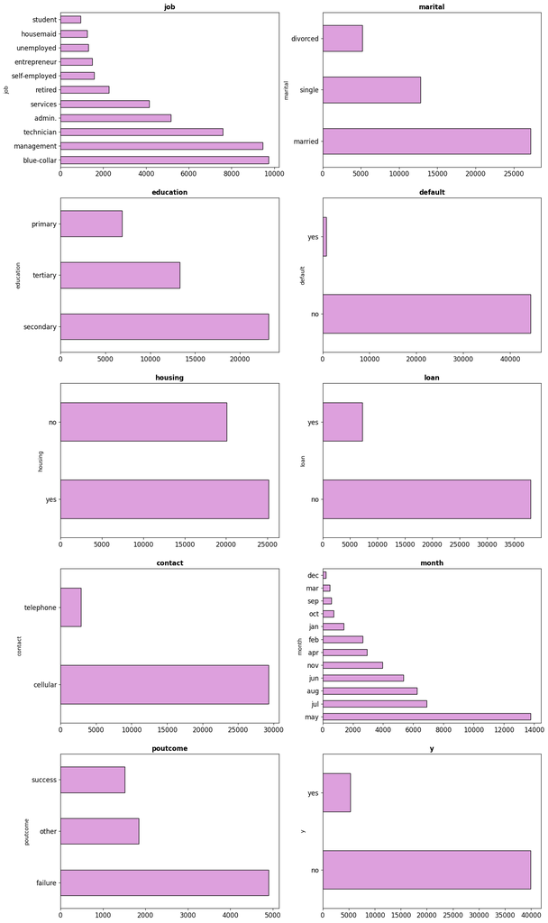

```python
graficos_eda_categoricos(bank)
```

#### Variables numéricas

- Cálculo de los estadísticos

```python
def estadisticos_cont(df):
    """
    Esta función calcula los parámetros estadisticos de las variables numéricas de un dataframe.
    :param df: (DataFrame) el dataframe del cual se quieren calcular los estadísticos de las variables numéricas
    :return df: (DataFrame) el dataframe con el resultado de estadísticos de las variables numéricas de un dataframe
    """

    numericas = df.select_dtypes('number')

    estadisticos = numericas.describe().T

    estadisticos['median'] = numericas.median()

    estadisticos = estadisticos.iloc[:,[0,1,8,2,3,4,5,6,7]] ## media y mediana juntas

    return(estadisticos)
```

```python
estadisticos_cont(bank.select_dtypes('number'))
```

|  | count | mean | median | std | min | 25% | 50% | 75% | max |
| --- | --- | --- | --- | --- | --- | --- | --- | --- | --- |
| age | 45211.0 | 40.936210 | 39.0 | 10.618762 | 18.0 | 33.0 | 39.0 | 48.0 | 95.0 |
| balance | 45211.0 | 1362.272058 | 448.0 | 3044.765829 | -8019.0 | 72.0 | 448.0 | 1428.0 | 102127.0 |
| day_of_week | 45211.0 | 15.806419 | 16.0 | 8.322476 | 1.0 | 8.0 | 16.0 | 21.0 | 31.0 |
| duration | 45211.0 | 258.163080 | 180.0 | 257.527812 | 0.0 | 103.0 | 180.0 | 319.0 | 4918.0 |
| campaign | 45211.0 | 2.763841 | 2.0 | 3.098021 | 1.0 | 1.0 | 2.0 | 3.0 | 63.0 |
| pdays | 45211.0 | 40.197828 | -1.0 | 100.128746 | -1.0 | -1.0 | -1.0 | -1.0 | 871.0 |
| previous | 45211.0 | 0.580323 | 0.0 | 2.303441 | 0.0 | 0.0 | 0.0 | 0.0 | 275.0 |

- Histogramas

```python
def graficos_eda_numericos(df):
    """
    Esta función grafica la dristribución de todas las variables numéricas que existen en un dataframe mediante un histograma
    :param df: (DataFrame) el dataframe del cual se quieren graficar todas las variables numéricas
    :return imagen: una imagen con todas las distribuciones posibles
    """

    numericas = df.select_dtypes('number')

    filas = ceil(numericas.shape[1] / 2)

    f, ax = plt.subplots(nrows = filas, ncols = 2, figsize = (16, filas * 4))

    ax = ax.flat

    for zona, variable in enumerate(numericas):
        numericas[variable].plot.hist(bins=30, ax=ax[zona], color='skyblue', edgecolor='black')
        ax[zona].set_title(variable, fontsize=12, fontweight="bold")
        ax[zona].tick_params(labelsize=12)

    plt.tight_layout()
    plt.show()
```

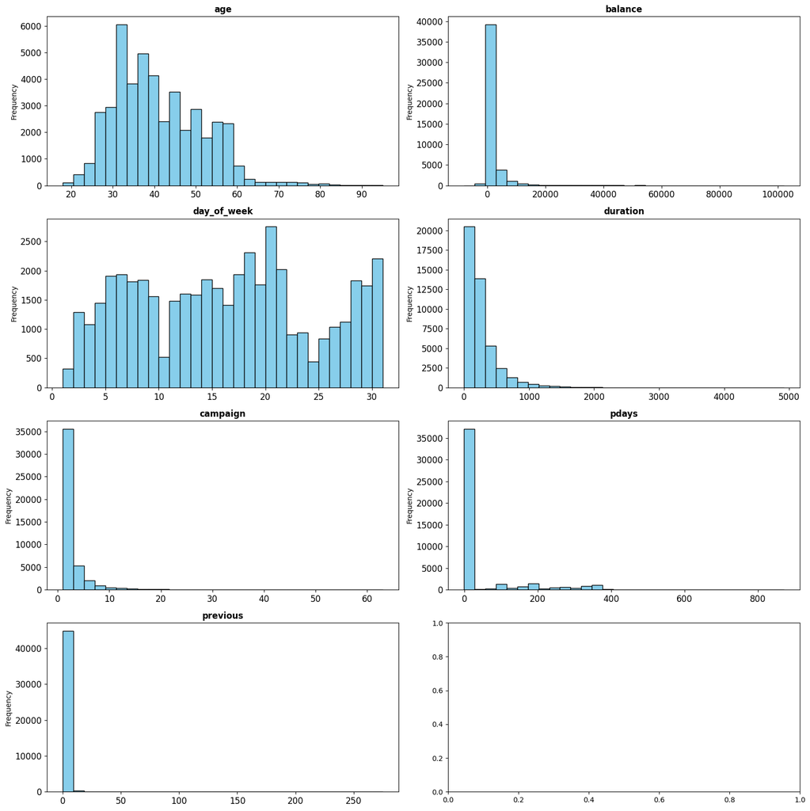

```python
graficos_eda_numericos(bank)
```

**Análisis:** comentad los resultados.

## Análisis exploratorio de los datos

En este subapartado exploraremos gráficamente la relación de los atributos descriptivos con la variable objetivo y analizaremos las diferentes correlaciones.

**Ejercicio:** usando una librería gráfica, como por ejemplo *matplotlib*, para cada una de las variables categóricas, superponed en un mismo gráfico el diagrama de barras para cada posible valor de la variable objetivo, diferenciando con distinto color según el valor de "y", es decir, cuando sea "no" o cuando sea "yes". Añadid una leyenda para saber a qué clase corresponde cada histograma.

La finalidad es observar cómo se distribuye cada uno de los atributos en función de la clase que tengan, para poder identificar de manera visual y rápida si algunos atributos nos permiten predecir mejor que otros el valor de la variable objetivo.

Sugerencia: podéis usar el parámetro "alpha" en los gráficos para que se aprecien los dos histogramas.

```python
def categoricos_objetivo(df, objetivo):
    """
    Esta función grafica la distribución de todas las variables categóricas que existen en un dataframe mediante gráfica de barras verticales
    comparando por la variable objetivo
    :param df: (DataFrame) el dataframe del cual se quieren graficar todas las variables categóricas
    :param  objetivo: (DataFrame) el dataframe de la variable objetivo
    :return imagen: una imagen con todas las distribuciones posibles
    """

    categoricas = df.select_dtypes('O')

    filas = ceil(categoricas.shape[1] / 2)
    fig, ax = plt.subplots(nrows=filas, ncols=2, figsize=(16, filas * 6))
    ax = ax.flat

    for posicion, columna in enumerate(categoricas.columns[:-1]):
        categories = df[columna].unique()
        valor_objetivo = df[objetivo].unique()

        bar_width = 0.35
        num_categorias = np.arange(len(categories))
        colores = {'no': 'PLUM', 'yes': '#6FD08C'}

        for i, valor in enumerate(valor_objetivo):
            valores = df[df[objetivo] == valor][columna].value_counts().reindex(categories, fill_value=0)
            valores_normalizados = valores /valores.sum() #Normalización de los resultados para su comparativa
            color = colores.get(valor)
            ax[posicion].bar([num + bar_width * i for num in num_categorias], valores_normalizados, bar_width, label=valor, color=color, edgecolor='black')

        ax[posicion].set_xlabel(columna, fontsize=12)
        ax[posicion].set_ylabel('Relative Frequency', fontsize=12)
        ax[posicion].set_title(f'{columna} by {objetivo}', fontsize=14, fontweight='bold')
        ax[posicion].set_xticks([num + bar_width * (len(valor_objetivo) - 1) / 2 for num in num_categorias])
        ax[posicion].set_xticklabels(categories, rotation=30, horizontalalignment = 'right')
        ax[posicion].legend()

    plt.tight_layout()
    plt.show()
```

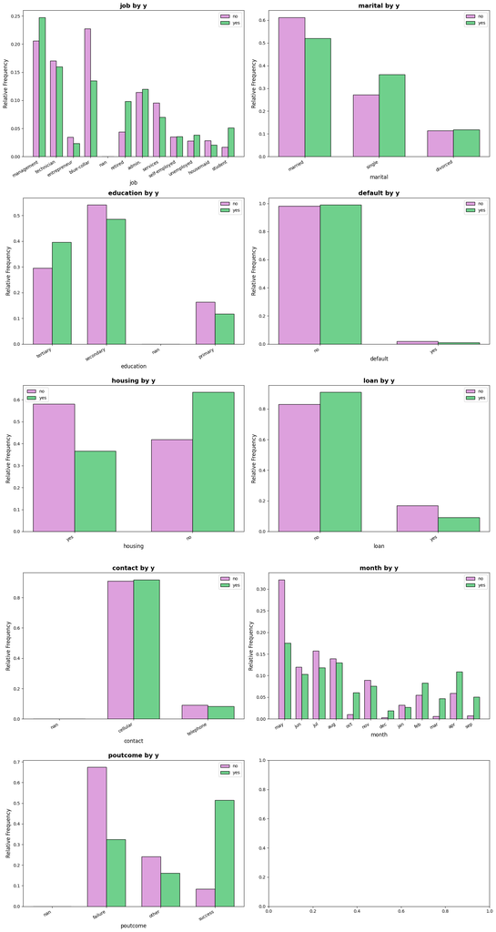

```python
categoricos_objetivo(bank, 'y')
```

**Ejercicio:** de la misma forma que en el ejercicio anterior, superponed los histogramas para los distintos valores de "y" para cada variable numérica.

```python
def numericos_objetivo(df, objetivo):
    """
    Esta función grafica la distribución de todas las variables numéricas que existen en un dataframe mediante gráfica de area
    comparando por la variable objetivo
    :param df: (DataFrame) el dataframe del cual se quieren graficar todas las variables categóricas
    :param  objetivo: (DataFrame) el dataframe de la variable objetivo
    :return imagen: una imagen con todas las distribuciones posibles
    """
    numericos = df.select_dtypes('number')

    filas = ceil(numericos.shape[1] / 2)
    fig, ax = plt.subplots(nrows=filas, ncols=2, figsize=(16, filas * 6))
    ax = ax.flat

    for posicion, columna in enumerate(numericos.columns):

        tabla_frecuencia = pd.crosstab(df[columna], df[objetivo])

        tabla_frecuencia.plot(kind = 'area', alpha=0.5, stacked=False, color=['PLUM', '#6FD08C'], figsize=(14,20), ax = ax[posicion])

        ax[posicion].set_title(f'{columna}', fontsize=14)
        ax[posicion].set_xlabel(columna, fontsize=12)
        ax[posicion].set_ylabel('Frequency', fontsize=12)
        ax[posicion].legend()

    plt.tight_layout()
    plt.show()
```

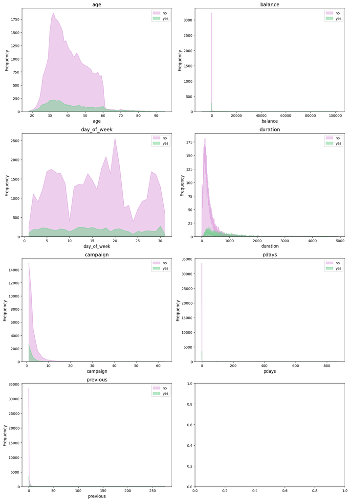

```python
numericos_objetivo(bank, 'y')
```

**Análisis:**  
Mirando los gráficos de barras y los histogramas, ¿qué atributos parecen tener más peso a la hora de predecir si se contratara un depósito a plazo o no? ¿Crees que con estos atributos será suficiente para poder determinar si se contratará o no el depósito?

Para saber que atributos muestran diferencias más significativas entre los valores presentados en cada distribución.

Respecto a los **atributos numéricos**:

- atributo "age": en el histograma se puede ver como hay una franja de edad que supera ampliamente el no contratar al contratar, que estáentre los 20 y los 60 años de edad. Por lo que la edad podría llegar a ser determinante.
- atributo "balance": la mayoria de los datos se arremolinan en torno a 0. Tanto para el si como para el no. Por lo que podría ser un candidato para ser descartado.
- atributo "day of week": Se puede ver como en este caso las personas que si han aceptado contratar, si que se mantienen en torno a un valor constante a lo largo del mes. Pero, sin embargo, las personas que no contratan si que se ven afectadas en función del día del mes, como por ejemplo en el día 10 o el 24. Por lo que podríamos llegar a considerarlo para saber que día es mejor llamar y que no nos rechacen la contratación.
- atributo "duration": En este caso, la mayoría se agrupa entre los 0 y los 1000 segundos de duración de la llamada, conforme mayor es la duración, más se alinean las personas que contraran y las que no. Sin embargo, si la llamada no pasa de los 1000 segundos, lo más probable es que el producto no se contrate, ya que como se ve en la gráfica, la distribución de "no contratación" es mucho mayor que los que sí contratan. Por lo que podríamos llegar a considerarlo para saber cuanto hay que alargar la conversación para asegurar que no nos rechacen la contratación.
- atributo "campaign": La proporción de contratar o no contratar en este caso es la misma para el níumero de contactos. Pero también se ve como si haces más de 10 va a ser casi imposible que te contrate, ya que para contratar podríamos estar entre los primeros 5 contactos. Podríamos llegar a considerarlo.
- atributo "pdays": Le ocurre igual que al atributo "balance". Se podría descartar.
- atributo "previous": Le ocurre igual que al atributo "campaign". Todo se mueven un intervalo pequeño por lo que habría que estudiar con más detalle si se podría descartar.

Por tanto, a modo de resumen y basándome en mi análisis previo, los atributos con más peso son el tipo de trabajo, el estado conyugal, la educación, si tienen hipoteca, el mes de contacto, la edad y los minutos de llamada. Con estos podría llegar a ser suficiente para predecir si va a contratar o no.

**Ejercicio:** calculad y mostrad la correlación entre las variables numéricas.

```python
corr_matrix = bank.select_dtypes('number').corr(method='pearson')
corr_matrix
```

|  | age | balance | day_of_week | duration | campaign | pdays | previous |
| --- | --- | --- | --- | --- | --- | --- | --- |
| age | 1.000000 | 0.097783 | -0.009120 | -0.004648 | 0.004760 | -0.023758 | 0.001288 |
| balance | 0.097783 | 1.000000 | 0.004503 | 0.021560 | -0.014578 | 0.003435 | 0.016674 |
| day_of_week | -0.009120 | 0.004503 | 1.000000 | -0.030206 | 0.162490 | -0.093044 | -0.051710 |
| duration | -0.004648 | 0.021560 | -0.030206 | 1.000000 | -0.084570 | -0.001565 | 0.001203 |
| campaign | 0.004760 | -0.014578 | 0.162490 | -0.084570 | 1.000000 | -0.088628 | -0.032855 |
| pdays | -0.023758 | 0.003435 | -0.093044 | -0.001565 | -0.088628 | 1.000000 | 0.454820 |
| previous | 0.001288 | 0.016674 | -0.051710 | 0.001203 | -0.032855 | 0.454820 | 1.000000 |

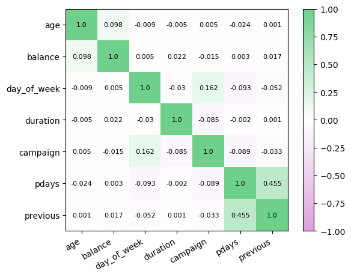

```python
fig, ax = plt.subplots()

color_list = ['PLUM','white', '#6FD08C']

cax = ax.imshow(corr_matrix, cmap=LinearSegmentedColormap.from_list("",color_list), vmin=-1, vmax=1)

for i in range(corr_matrix.shape[0]):
    for j in range(corr_matrix.shape[1]):
        text = ax.text(j, i, round(corr_matrix.iloc[i, j], 3),
                       ha="center", va="center", color="black", fontsize=8)


cbar = fig.colorbar(cax)

ax.set_xticks(np.arange(len(corr_matrix.columns)))
ax.set_yticks(np.arange(len(corr_matrix.columns)))
ax.set_xticklabels(corr_matrix.columns, rotation=30, ha="right", fontsize=10)  # Rotar las etiquetas de columnas
ax.set_yticklabels(corr_matrix.columns, fontsize=10)

ax.set_aspect('equal')

plt.show()
```

**Análisis:** comenta los resultados.

Prácticamente todas las correlaciones entre las variables numéricas presentan valores muy bajos (< 0.2) y la mayor correlación encontrada (correlación pdays - previous) está en torno a 0.45. Esto indica que las variables numéricas no están fuertemente correlacionadas y que, por tanto, no presentaran problemas de colinealidad. Además también significa que evitamos la redundancia y no debería haber un sobreajsute del modelo.

# Preprocesado de los datos (1.5 puntos)

Una vez analizados los atributos descriptivos, es el momento de prepararlos para que nos sean útiles de cara a predecir valores.

Desde este punto en adelante, por simplicidad, vamos a trabajar únicamente con los atributos numéricos.

En este apartado:

Estandarizaremos los valores de los atributos descriptivos numéricos para que sus escalas no sean muy diferentes.

Separaremos el conjunto de datos original en dos subconjuntos: entrenamiento y test.

**Pregunta:** ¿qué técnica podríamos utilizar para representar los atributos categóricos de forma numérica?

En este caso, lo que se podría hacer es codificar cada categoria del atributo y asignarle un número.

En el caso de python podemos usar la función ".cat.codes" de la librería pandas añadiendo una nueva columna o codificarlo con un diccionario y remplazarlo en la propia columna con la función ".replace()".

**Ejercicio:** quédate con los atributos descriptivos numéricos y estandarízalos, este será el nuevo conjunto de atributos descriptivos con el que trabajaremos desde ahora.

Sugerencia: utilizad "StandardScaler" de *preprocessing*.

```python
objeto = preprocessing.StandardScaler()

X_norm = pd.DataFrame(objeto.fit_transform(X.select_dtypes('number')), columns=X.select_dtypes('number').columns)

X_norm.sample(5)
```

|  | age | balance | day_of_week | duration | campaign | pdays | previous |
| --- | --- | --- | --- | --- | --- | --- | --- |
| 2938 | 0.665225 | 6.357120 | -0.217055 | -0.517088 | -0.569351 | -0.411453 | -0.251940 |
| 38807 | -1.689124 | -0.076943 | 0.263576 | -0.703478 | 0.076230 | -0.411453 | -0.251940 |
| 37820 | -0.464863 | -0.447419 | -0.217055 | 1.106056 | -0.246560 | -0.411453 | -0.251940 |
| 24136 | -0.653211 | 0.133913 | -1.178318 | -0.901517 | -0.569351 | 0.607247 | 4.523577 |
| 23698 | -0.653211 | -0.243461 | 1.465155 | -0.206439 | 0.076230 | -0.411453 | -0.251940 |

**Ejercicio:** separa los atributos descriptivos escalados y la variable objetivo en los subconjuntos de entrenamiento y test.

Sugerencia: para separar entre train y test podéis usar "train_test_split" de sklearn.

```python
X_train, X_test, y_train, y_test = train_test_split(X_norm, Y, test_size=0.3)
```

**Análisis:** explica si la decisión de transformar el conjunto de datos (estandarización) antes de realizar la separación del conjunto de datos en los subconjuntos de entrenamiento y test es una buena idea.

Tiene sentido normalizar antes de separar el conjunto de datos debido a que así estandarizas de forma global todos los datos que se van a utilizar en el modelo. En caso de estandarizar después de la separación habría que realizar la estandarización en dos grupos de datos separados y podrían no considerar los mismos rangos de maximos y minimos para una misma variable, haciendo que la estandarización fuese distinta. De esta manera, normalizando antes de separar, haces que los datos sigan siendo consistentes.

**Análisis:** en este ejercicio hemos estandarizado los valores de los atributos descriptivos para que sus escalas no sean muy diferentes. ¿Qué nos aporta estandarizar los atributos descriptivos? ¿hay alguna situación o escenario en la que sea imprescindible?

Si estandarizamos los datos, lo que buscamos es que el modelo que vayamos a preparar pueda aprender de forma más eficiente, puesto que los datos siguen una distribución N(0,1). Por otro lado, todos los atributos están en la misma escala, lo que evita que los atributos que tengan números más grandes dominen el modelo.

Se recomienda estandarizar las variables cuando éstas están en distinta escala y tienen distintas unidades. Por otro lado, los métodos como el K-means necesita que los datos estén normalizados para evitar justo esto, las diferencias de rango numéricos entre variables y sus unidades.

# Reducción de la dimensionalidad (2.5 puntos)

En este apartado retomaremos el análisis gráfico de distribución de la clase a lo largo de las muestras del conjunto de datos. En el segundo apartado pudimos observar si las variables descriptivas por separado eran muy prometedoras o no de cara a predecir la clase. Aquí vamos a intentar determinar si su combinación puede ayudarnos a determinar si se contratará el depósito de mejor manera que utilizando los atributos por separados. Con este propósito, vamos a reducir la dimensionalidad del problema a solamente dos atributos, que serán la proyección de los atributos descriptivos originales, y observaremos de qué manera se distribuyen las muestras de cada clase.

**Ejercicio:**

- Aplicad el método de reducción de la dimensionalidad Principal Component Analysis (PCA) para reducir a 2 dimensiones el dataset entero con todas las features.
- Generad un gráfico en 2D con el resultado del PCA usando colores diferentes para cada una de las clases de la respuesta, con el objetivo de visualizar si es posible separar eficientemente las clases con este método.

NOTA: Tened cuidado, no incluyáis la variable objetivo en la reducción de dimensionalidad. Queremos explicar la variable objetivo en función del resto de variables reducidas a dos dimensiones.

Sugerencia: no es necesario que programéis el algoritmo de PCA, podéis usar la implementación disponible en la librería de *scikit-learn*.

```python
pca = PCA(n_components=2)

principalComponents = pca.fit_transform(X_norm)

X_PCA = pd.DataFrame(data = principalComponents, columns = ['PCA 1', 'PCA 2'])

bank_PCA = pd.concat([X_PCA, Y], axis = 1)

bank_PCA.head()
```

|  | PCA 1 | PCA 2 | y |
| --- | --- | --- | --- |
| 0 | 0.033707 | -1.402827 | no |
| 1 | 0.017589 | -0.954478 | no |
| 2 | 0.022938 | -0.699632 | no |
| 3 | 0.011669 | -0.954774 | no |
| 4 | 0.051021 | -0.912816 | no |

```python
print('Explained variation per principal component: {}'.format(pca.explained_variance_ratio_))
```

```
Explained variation per principal component: [0.21561335 0.16500204]
```

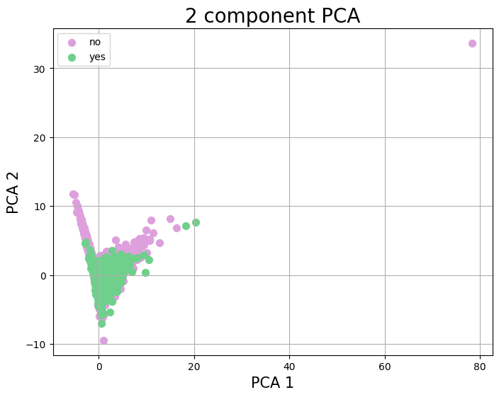

```python
fig = plt.figure(figsize = (8,6))
plt.xlabel('PCA 1', fontsize = 15)
plt.ylabel('PCA 2', fontsize = 15)
plt.title('2 component PCA', fontsize = 20)

targets = ['no', 'yes']
color=['PLUM', '#6FD08C']
for target, color in zip(targets,color):
    indicesToKeep = bank_PCA['y'] == target
    plt.scatter(bank_PCA.loc[indicesToKeep, 'PCA 1'],
                bank_PCA.loc[indicesToKeep, 'PCA 2'],
                c = color,
                s = 50)
plt.legend(targets)
plt.grid()
```

**Ejercicio:**

- Repetid la reducción de dimensionalidad, pero en este caso usando TSNE. Podéis encontrar más información sobre este algoritmo en el link: https://distill.pub/2016/misread-tsne/
- Al igual que antes, generad un gráfico en 2D con el resultado del PCA usando colores diferentes para cada una de las clases de la respuesta (y), con el objetivo de visualizar si es posible separar eficientemente las clases con este método.

Sugerencia: no es necesario que programéis el algoritmo TSNE, podéis usar la implementación disponible en la librería de *scikit-learn*.  
Sugerencia: a parte de especificar el número de componentes, probad a usar los parámetros "learning_rate" y "perplexity".

```python
time_start = time.time()
tsne = TSNE(n_components=2, perplexity=50, max_iter=5000, learning_rate = 1000)
 #perplexity values in the range (5 - 50)
 #point of stability by step 5000
 #learning_rate (auto) = max(45211 / early_exaggeration = 12 / 4, 50) = 942
 # The learning rate for t-SNE is usually in the range [10.0, 1000.0]
```

```python
X_TSNE = tsne.fit_transform(X_norm)

print('t-SNE done! Time elapsed: {} seconds'.format(time.time()-time_start))
```

```
t-SNE done! Time elapsed: 1322.1572256088257 seconds
```

```python
X_TSNE

X_TSNE = pd.DataFrame(X_TSNE, columns=['TSNE 1', 'TSNE 2'])

bank_TSNE = pd.concat([X_TSNE, Y], axis = 1)

bank_TSNE.head()
```

|  | TSNE 1 | TSNE 2 | y |
| --- | --- | --- | --- |
| 0 | 75.144188 | -52.232609 | no |
| 1 | 46.286907 | -147.440765 | no |
| 2 | 3.603576 | -174.588394 | no |
| 3 | 61.127415 | -120.222298 | no |
| 4 | -3.708425 | -164.563019 | no |

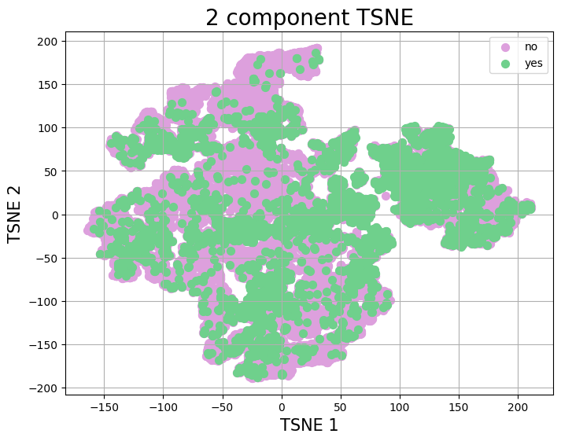

```python
fig = plt.figure(figsize = (8,6))
plt.xlabel('TSNE 1', fontsize = 15)
plt.ylabel('TSNE 2', fontsize = 15)
plt.title('2 component TSNE', fontsize = 20)

targets = ['no', 'yes']
color=['PLUM', '#6FD08C']
for target, color in zip(targets,color):
    indicesToKeep = bank_TSNE['y'] == target
    plt.scatter(bank_TSNE.loc[indicesToKeep, 'TSNE 1'],
                bank_TSNE.loc[indicesToKeep, 'TSNE 2'],
                c = color,
                s = 50)
plt.legend(targets)
plt.grid()
```

**Análisis:** observando los dos gráficos, ¿crees que ha funcionado bien la reducción de dimensionalidad? ¿Ha conseguido separar las clases correctamente? ¿Cuál de los dos métodos ha funcionado mejor? ¿Por qué obtenemos resultados tan diferentes?

En este caso se han probado dos técnicas para recudir la dimensionalidad del conjunto de datos, PCA y t-SNE. Sin embargo, como se ha podido ver a lo largo del ejericio, ninguno de los métodos han podido separar bien el conjunto de datos. Aunque si que es cierto, que posiblemente el método t-SNE haya podido separarlo algo mejor.

Por otra parte, podemos ver en las figuras que la forma de separar el conjunto ha sido muy distinta y se han obtenido resultados diferentes en cuanto al agrupamiento se refiere. Esto puede ser debido a la forma en la que funciona cada método. Al final, PCA busca transformar las variables que están correlacionadas entre si hasta obtener un número determiando de variables (en nuestor caso, 2) no correlacionadas, buscando, a su vez, maximizar la varianza. t-SNE busca reducir la dimensión del conjunto de datos a través de iteraciones y parámetros ajustables como la perplejidad, el cual busca equilibrar los datos, conservando la estructura de los mismos.

**Pregunta:** ¿qué opinas de TSNE como opción para reducir la dimensionalidad? ¿Qué te parece que sólo tenga el método "fit_transform" pero no tenga "transform"? ¿Conoces alguna otra opción que, con unas prestaciones similares, evite los problemas que tiene TSNE?

Es un método muy interesante y a tener en cuenta, sobre todo cuando tienes un gran conjunto de datos. Sin embargo, tiene sus contras, puesto que si no se eligen bien los parámetros de perpejidad e iteraciones no se llegará a ninguna solución óptima y válida de separación.

El método transform precisa de realizar primero el método fit al conjunto de datos de entrenamiento. Sin embargo, para el método t-SNE no se utiliza para predecir los datos ya que el principal propósito de este método es la visualización de los datos con una menor dimensión, por lo que tener el método "fit_transform" es suficiente para t-SNE.

Existen otros métodos alternativos al t-SNE, como por ejemplo el método UMAP, el cual también busca visualizar los conjunto de datos con una menor dimensión, es mñas rápido y conserva mejor la estricutura global de los datos que el t-SNE.

# Conjuntos desbalanceados de datos (2.5 puntos)

En los problemas de clasificación, es muy común encontrar conjuntos de datos muy desbalanceados. En la industria existen múltiples ejemplos, como la detección de fraude o la fuga de clientes. Este apartado se centra en el análisis de este tipo de conjuntos.

El caso del *dataset* con el que estamos trabajando (*Bank Marketing*) es uno de ellos, ya que podemos ver cómo la clase "no" aparece hasta un orden de magnitud más que la clase "yes".

A continuación, vamos a analizar la distribución de nuestro conjunto de datos. Para ello, utilizaremos la función **show_distribution** definida en la siguiente celda:

```python
def show_distribution(y_df):
    freq = y_df["y"].value_counts()
    plt.pie(freq, labels=('No subscription ('+str(freq["no"])+')', 'Subscription ('+str(freq["yes"])+')'), autopct='%1.1f%%')
    plt.title("Term deposit subscription distribution")
    plt.show()
```

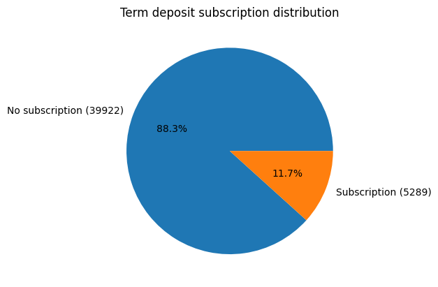

```python
show_distribution(Y)
```

Cómo se puede observar, el conjunto está bastante desbalanceado, ya que, prácticamente, sólo una décima parte de las muestras se corresponden con la contratación del depósito.

Para abordar el problema de datos desbalanceados, vamos a analizar la técnica de sobremuestreo (oversampling) de la clase minoritaria. En la literatura hay más técnicas para abordar este problema, como el submuestreo (undersampling) de la clase mayoritaria, pero en esta PEC nos vamos a centrar sólo en la técnica de sobremuestreo.

## Oversampling

**Ejercicio:** incrementad las muestras de la clase minoritaria hasta alcanzar un número similar al de elementos de la clase mayoritaria, aplicando las siguientes técnicas:

- Duplicación aleatoria (random over-sampling), fijando random_state=10.
- SMOTE (Synthetic Minority Over-sampling Technique), fijando random_state=10.
- ADASYN (Adaptive Synthetic Sampling), fijando random_state=10.

Por último, comprobad, con ayuda de la función **show_distribution**, que después de la aplicación de dichas técnicas el número de muestras de la clase minoritaria se ha igualado al de la mayoritaria.

Sugerencia: para aplicar la duplicación aleatoria podéis usar "RandomOverSampler" de *imblearn*.  
Sugerencia: para aplicar smote podéis usar "SMOTE" de *imblearn*.  
Sugerencia: para aplicar adasun podéis usar "ADASYN" de *imblearn*.

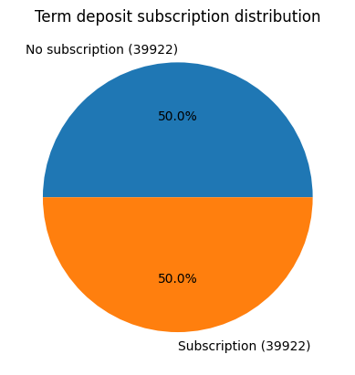

```python
# Duplicación aleatoria
ros = RandomOverSampler(random_state=10)
X_ros, Y_ros = ros.fit_resample(X_norm, Y)
show_distribution(Y_ros)
```

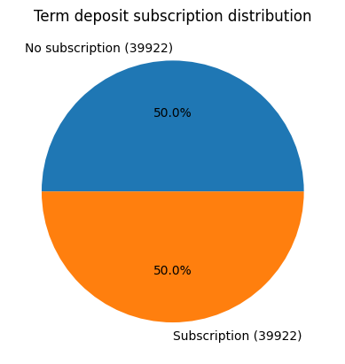

```python
# SMOTE
smote = SMOTE(random_state=10)
X_sm, Y_sm = smote.fit_resample(X_norm, Y)
show_distribution(Y_sm)
```

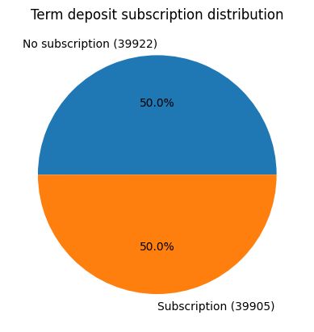

```python
#ADASYN
adasyn = ADASYN(random_state=10)
X_ad, Y_ad = adasyn.fit_resample(X_norm, Y)
show_distribution(Y_ad)
```

El resultado de aplicar dichas técnicas nos debería de haber dado un número similar de muestras para ambas clases, sin embargo, cada uno de los métodos genera las nuevas muestras de la clase minoritaria de diferente forma. Con el objetivo de comprender mejor y de manera visual cómo se generan estas nuevas muestras utilizaremos, a partir de ahora, la descomposición a dos dimensiones que mejor se haya comportado en el apartado anterior.

**Ejercicio:** mostrad, mediante un gráfico de dispersión en función de las dos componentes resultantes de la reducción dimensional previa, la distribución de las contrataciones del conjunto de datos original y el obtenido al aplicar Random Over Sampling.

```python
X_ros_TSNE = tsne.fit_transform(X_ros)

print('t-SNE done! Time elapsed: {} seconds'.format(time.time()-time_start))
```

```
t-SNE done! Time elapsed: 4127.88711643219 seconds
```

```python
X_ros_TSNE = pd.DataFrame(X_ros_TSNE, columns=['TSNE 1', 'TSNE 2'])
bank_ros_TSNE = pd.concat([X_ros_TSNE, Y_ros], axis = 1)
bank_ros_TSNE.head()
```

|  | TSNE 1 | TSNE 2 | y |
| --- | --- | --- | --- |
| 0 | -57.527012 | 49.574951 | no |
| 1 | -175.677872 | 20.796089 | no |
| 2 | -210.047668 | 2.391855 | no |
| 3 | -147.173981 | 35.265167 | no |
| 4 | -208.351135 | -16.439034 | no |

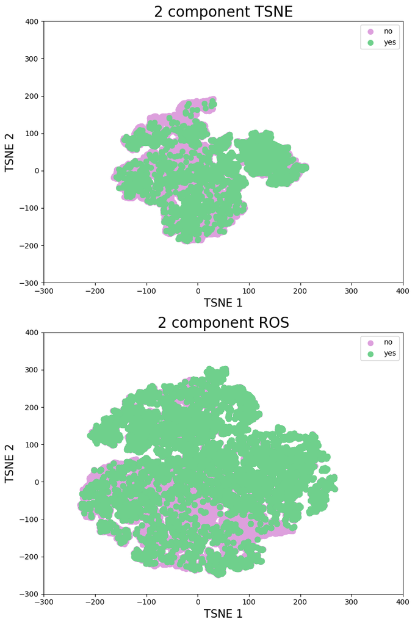

```python
fig, ax = plt.subplots(nrows=2, ncols=1, figsize=(8, 12))
ax = ax.flat

targets = ['no', 'yes']
color=['PLUM', '#6FD08C']

x_min = min(bank_TSNE['TSNE 1'].min(), bank_ros_TSNE['TSNE 1'].min())
x_max = max(bank_TSNE['TSNE 1'].max(), bank_ros_TSNE['TSNE 1'].max())
y_min = min(bank_TSNE['TSNE 2'].min(), bank_ros_TSNE['TSNE 2'].min())
y_max = max(bank_TSNE['TSNE 2'].max(), bank_ros_TSNE['TSNE 2'].max())

x_min_rounded = round(x_min, -2) - 100
x_max_rounded = round(x_max, -2) + 100
y_min_rounded = round(y_min, -2) - 100
y_max_rounded = round(y_max, -2) + 100

ax[0].set_xlabel('TSNE 1', fontsize = 15)
ax[0].set_ylabel('TSNE 2', fontsize = 15)
ax[0].set_title('2 component TSNE', fontsize = 20)
ax[0].set_xlim([x_min_rounded, x_max_rounded])
ax[0].set_ylim([y_min_rounded, y_max_rounded])

for target, color in zip(targets,color):
    indicesToKeep = bank_TSNE['y'] == target
    ax[0].scatter(bank_TSNE.loc[indicesToKeep, 'TSNE 1'],
                bank_TSNE.loc[indicesToKeep, 'TSNE 2'],
                c = color,
                s = 50)

    ax[0].legend(targets)
    ax[0].grid()


targets = ['no', 'yes']
color=['PLUM', '#6FD08C']

ax[1].set_xlabel('TSNE 1', fontsize = 15)
ax[1].set_ylabel('TSNE 2', fontsize = 15)
ax[1].set_title('2 component ROS', fontsize = 20)
ax[1].set_xlim([x_min_rounded, x_max_rounded])
ax[1].set_ylim([y_min_rounded, y_max_rounded])

for target, color in zip(targets,color):
    indicesToKeep = bank_ros_TSNE['y'] == target
    ax[1].scatter(bank_ros_TSNE.loc[indicesToKeep, 'TSNE 1'],
                bank_ros_TSNE.loc[indicesToKeep, 'TSNE 2'],
                c = color,
                s = 50)

    ax[1].legend(targets)
    ax[1].grid()


plt.tight_layout()
plt.show()
```

**Análisis:** ¿qué diferencias y similitudes encuentras en las dos imágenes anteriores? Justificad la respuesta teniendo en cuenta la distribución de ambos conjuntos, es decir, la cantidad de averías de motor.

La primera diferencia que se puede apreciar comparando ambas distribuciones es la cantidad de puntos verdes, relativos al número de "si" que hay. En el segundo caso, al aumentar el número de muestras para el "si" se puede ver claramente que ha funcionado puesto que, como se ha dicho hay más densidad de puntos. Por otro lado, se puede ver que ambos casos tienen una distribución parecida, aunque es cierto que el segundo caso, se ha expandido más. En ambos casos, se puede ver como el método t-SNE no es capaz de separar las muestras entre el "si" y el "no".

**Ejercicio:** mostrad, mediante un gráfico de dispersión en función de las dos componentes resultantes de la reducción dimensional previa, la distribución de las contrataciones de los tres conjuntos de datos obtenidos al aplicar las tres técnicas de sobremuestreo.

```python
X_sm_TSNE = tsne.fit_transform(X_sm)

print('t-SNE done! Time elapsed: {} seconds'.format(time.time()-time_start))
```

```
t-SNE done! Time elapsed: 7120.011768817902 seconds
```

```python
X_sm_TSNE = pd.DataFrame(X_sm_TSNE, columns=['TSNE 1', 'TSNE 2'])
bank_sm_TSNE = pd.concat([X_sm_TSNE, Y_sm], axis = 1)
bank_sm_TSNE.head()
```

|  | TSNE 1 | TSNE 2 | y |
| --- | --- | --- | --- |
| 0 | -37.610497 | 45.180222 | no |
| 1 | -148.587219 | 26.617804 | no |
| 2 | -188.865051 | 4.397000 | no |
| 3 | -110.825722 | 37.050922 | no |
| 4 | -182.063187 | -2.516172 | no |

```python
X_ad_TSNE = tsne.fit_transform(X_ad)

print('t-SNE done! Time elapsed: {} seconds'.format(time.time()-time_start))
```

```
t-SNE done! Time elapsed: 9834.862696886063 seconds
```

```python
X_ad_TSNE = pd.DataFrame(X_ad_TSNE, columns=['TSNE 1', 'TSNE 2'])
bank_ad_TSNE = pd.concat([X_ad_TSNE, Y_ad], axis = 1)
bank_ad_TSNE.head()
```

|  | TSNE 1 | TSNE 2 | y |
| --- | --- | --- | --- |
| 0 | 50.205898 | 23.359509 | no |
| 1 | 111.853882 | -79.171158 | no |
| 2 | 113.355705 | -109.582741 | no |
| 3 | 93.359367 | -58.262585 | no |
| 4 | 106.674423 | -123.810234 | no |

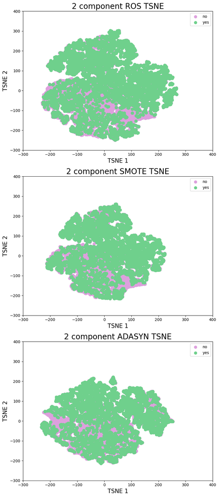

```python
fig, ax = plt.subplots(nrows=3, ncols=1, figsize=(8, 18))
ax = ax.flat

targets = ['no', 'yes']
color=['PLUM', '#6FD08C']

x_min = min(bank_ros_TSNE['TSNE 1'].min(), bank_sm_TSNE['TSNE 1'].min(), bank_ad_TSNE['TSNE 1'].min())
x_max = max(bank_ros_TSNE['TSNE 1'].max(), bank_sm_TSNE['TSNE 1'].max(), bank_ad_TSNE['TSNE 1'].max())
y_min = min(bank_ros_TSNE['TSNE 2'].min(), bank_sm_TSNE['TSNE 2'].min(), bank_ad_TSNE['TSNE 2'].min())
y_max = max(bank_ros_TSNE['TSNE 2'].max(), bank_sm_TSNE['TSNE 2'].max(), bank_ad_TSNE['TSNE 2'].max())

x_min_rounded = round(x_min, -2) - 100
x_max_rounded = round(x_max, -2) + 100
y_min_rounded = round(y_min, -2) - 100
y_max_rounded = round(y_max, -2) + 100

ax[0].set_xlabel('TSNE 1', fontsize = 15)
ax[0].set_ylabel('TSNE 2', fontsize = 15)
ax[0].set_title('2 component ROS TSNE', fontsize = 20)
ax[0].set_xlim([x_min_rounded, x_max_rounded])
ax[0].set_ylim([y_min_rounded, y_max_rounded])

for target, color in zip(targets,color):
    indicesToKeep = bank_ros_TSNE['y'] == target
    ax[0].scatter(bank_ros_TSNE.loc[indicesToKeep, 'TSNE 1'],
                bank_ros_TSNE.loc[indicesToKeep, 'TSNE 2'],
                c = color,
                s = 50)

    ax[0].legend(targets)
    ax[0].grid()


targets = ['no', 'yes']
color=['PLUM', '#6FD08C']

ax[1].set_xlabel('TSNE 1', fontsize = 15)
ax[1].set_ylabel('TSNE 2', fontsize = 15)
ax[1].set_title('2 component SMOTE TSNE', fontsize = 20)
ax[1].set_xlim([x_min_rounded, x_max_rounded])
ax[1].set_ylim([y_min_rounded, y_max_rounded])

for target, color in zip(targets,color):
    indicesToKeep = bank_sm_TSNE['y'] == target
    ax[1].scatter(bank_sm_TSNE.loc[indicesToKeep, 'TSNE 1'],
                bank_sm_TSNE.loc[indicesToKeep, 'TSNE 2'],
                c = color,
                s = 50)

    ax[1].legend(targets)
    ax[1].grid()


targets = ['no', 'yes']
color=['PLUM', '#6FD08C']

ax[2].set_xlabel('TSNE 1', fontsize = 15)
ax[2].set_ylabel('TSNE 2', fontsize = 15)
ax[2].set_title('2 component ADASYN TSNE', fontsize = 20)
ax[2].set_xlim([x_min_rounded, x_max_rounded])
ax[2].set_ylim([y_min_rounded, y_max_rounded])

for target, color in zip(targets,color):
    indicesToKeep = bank_ad_TSNE['y'] == target
    ax[2].scatter(bank_ad_TSNE.loc[indicesToKeep, 'TSNE 1'],
                bank_ad_TSNE.loc[indicesToKeep, 'TSNE 2'],
                c = color,
                s = 50)

    ax[2].legend(targets)
    ax[2].grid()

plt.tight_layout()
plt.show()
```

**Análisis:** teniendo en cuenta el número de muestras con contratación en cada conjunto, comentad las diferencias y similitudes en las imágenes del ejercicio anterior. Justificad la respuesta teniendo en cuenta el comportamiento de cada una de las técnicas utilizadas.